# Dissertation Analysis: Team Orientation Analysis

Jamiahus Walton

2019-06-25

# Motivation

The motivation behind this analysis is to gain insight that will help explain the significance found in the previous analysis.

# What is the distribution of the post session responses?

## Did the participants notice the feedback?

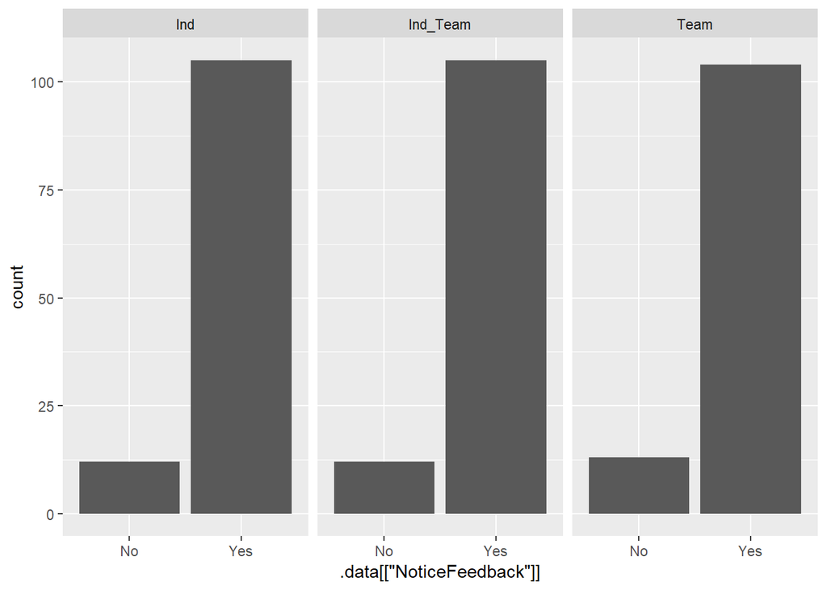

```r
y_label_ind <- "Count"
x_label_ind <- "NoticeFeedback"
setwd(figure_directory)

plot_data_ind <- ind_data %>%
  select(x_label_ind,
         Target)

ggplot(data = plot_data_ind, aes(x = .data[[x_label_ind]])) +
  geom_bar()+
  facet_grid(. ~ Target)
```

```r
summary_data<- plot_data_ind %>%
  group_by(Target, .data[[x_label_ind]])%>%
  summarise(N = length(.data[[x_label_ind]]),
            percent = length(.data[[x_label_ind]])/ N_ind * 100)

summary_data %>%
  kable() %>%
  kable_styling()
```

| Target | NoticeFeedback | N | percent |
| --- | --- | --- | --- |
| Ind | No | 12 | 10.25641 |
| Ind | Yes | 105 | 89.74359 |
| Ind_Team | No | 12 | 10.25641 |
| Ind_Team | Yes | 105 | 89.74359 |
| Team | No | 13 | 11.11111 |
| Team | Yes | 104 | 88.88889 |

Generally, the results show that most of the participants noticed the feedback overall. The highest pecent of participants that did not notice the feedback was a little over 11%.

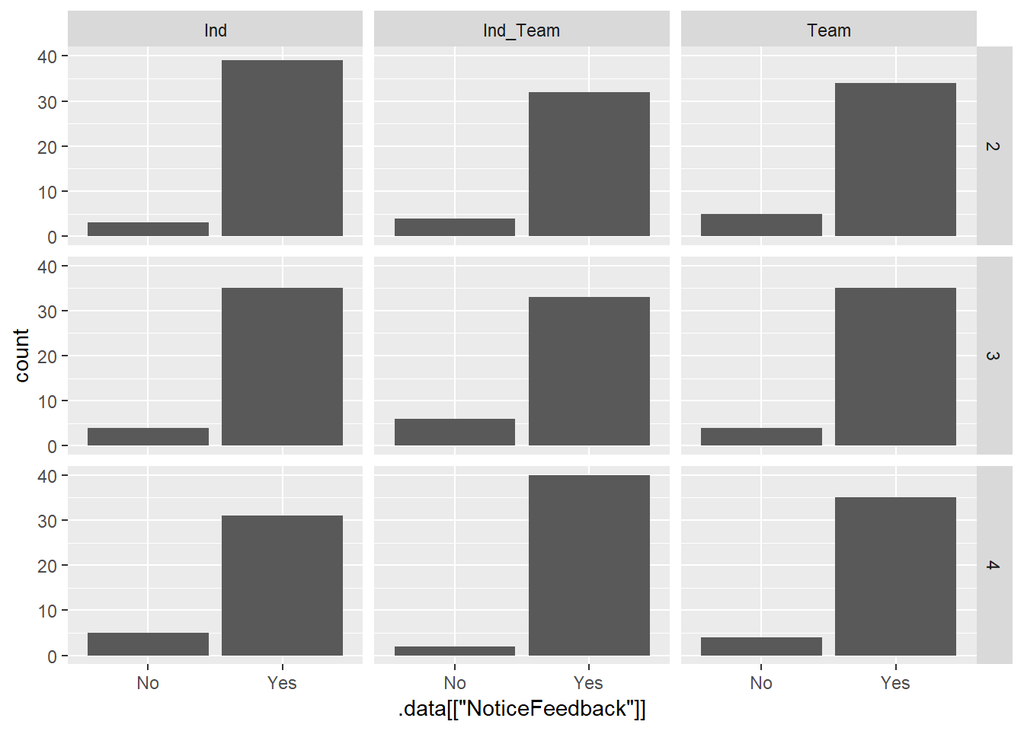

```r
y_label_ind <- "Count"
x_label_ind <- "NoticeFeedback"
setwd(figure_directory)

plot_data_ind <- ind_data %>%
  select(x_label_ind,
         SessionOrder,
         Target)

ggplot(data = plot_data_ind, aes(x = .data[[x_label_ind]])) +
  geom_bar()+
  facet_grid(SessionOrder ~ Target)
```

```r
summary_data<- plot_data_ind %>%
  group_by(SessionOrder, Target, .data[[x_label_ind]])%>%
  summarise(N = length(.data[[x_label_ind]]),
            percent = length(.data[[x_label_ind]])/ N_ind * 100)

summary_data %>%
  kable() %>%
  kable_styling()
```

| SessionOrder | Target | NoticeFeedback | N | percent |
| --- | --- | --- | --- | --- |
| 2 | Ind | No | 3 | 2.564103 |
| 2 | Ind | Yes | 39 | 33.333333 |
| 2 | Ind_Team | No | 4 | 3.418803 |
| 2 | Ind_Team | Yes | 32 | 27.350427 |
| 2 | Team | No | 5 | 4.273504 |
| 2 | Team | Yes | 34 | 29.059829 |
| 3 | Ind | No | 4 | 3.418803 |
| 3 | Ind | Yes | 35 | 29.914530 |
| 3 | Ind_Team | No | 6 | 5.128205 |
| 3 | Ind_Team | Yes | 33 | 28.205128 |
| 3 | Team | No | 4 | 3.418803 |
| 3 | Team | Yes | 35 | 29.914530 |
| 4 | Ind | No | 5 | 4.273504 |
| 4 | Ind | Yes | 31 | 26.495726 |
| 4 | Ind_Team | No | 2 | 1.709402 |
| 4 | Ind_Team | Yes | 40 | 34.188034 |
| 4 | Team | No | 4 | 3.418803 |
| 4 | Team | Yes | 35 | 29.914530 |

Generally, it looks as though participants noticed the feedback in each condition during each session.

### Sumamry

Generally, the participants did notice the feedback.

## Did the participants find the feedback helpful?

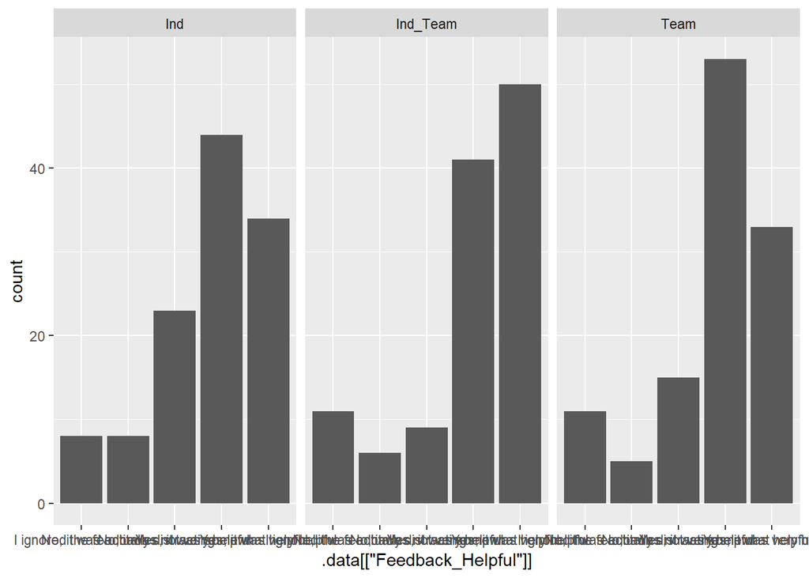

```r
y_label_ind <- "Count"
x_label_ind <- "Feedback_Helpful"
setwd(figure_directory)

plot_data_ind <- ind_data %>%
  select(x_label_ind,
         Target)

  ggplot(data = plot_data_ind, aes(x = .data[[x_label_ind]])) +
  geom_bar()+
  facet_grid(. ~ Target)
```

```r
summary_data<- plot_data_ind %>%
  group_by(Target, .data[[x_label_ind]])%>%
  summarise(N = length(.data[[x_label_ind]]),
            percent = length(.data[[x_label_ind]])/ N_ind * 100)

summary_data %>%
  kable() %>%
  kable_styling()
```

| Target | Feedback_Helpful | N | percent |
| --- | --- | --- | --- |
| Ind | I ignored the feedback | 8 | 6.837607 |
| Ind | No, it was actually distracting | 8 | 6.837607 |
| Ind | No, it was not very helpful | 23 | 19.658120 |
| Ind | Yes, it was somewhat helpful | 44 | 37.606838 |
| Ind | Yes, it was very helpful | 34 | 29.059829 |
| Ind_Team | I ignored the feedback | 11 | 9.401709 |
| Ind_Team | No, it was actually distracting | 6 | 5.128205 |
| Ind_Team | No, it was not very helpful | 9 | 7.692308 |
| Ind_Team | Yes, it was somewhat helpful | 41 | 35.042735 |
| Ind_Team | Yes, it was very helpful | 50 | 42.735043 |
| Team | I ignored the feedback | 11 | 9.401709 |
| Team | No, it was actually distracting | 5 | 4.273504 |
| Team | No, it was not very helpful | 15 | 12.820513 |
| Team | Yes, it was somewhat helpful | 53 | 45.299145 |
| Team | Yes, it was very helpful | 33 | 28.205128 |

The data suggests that in each condtion, the participants generally found the feedback to very helpful or somewhat helpful.

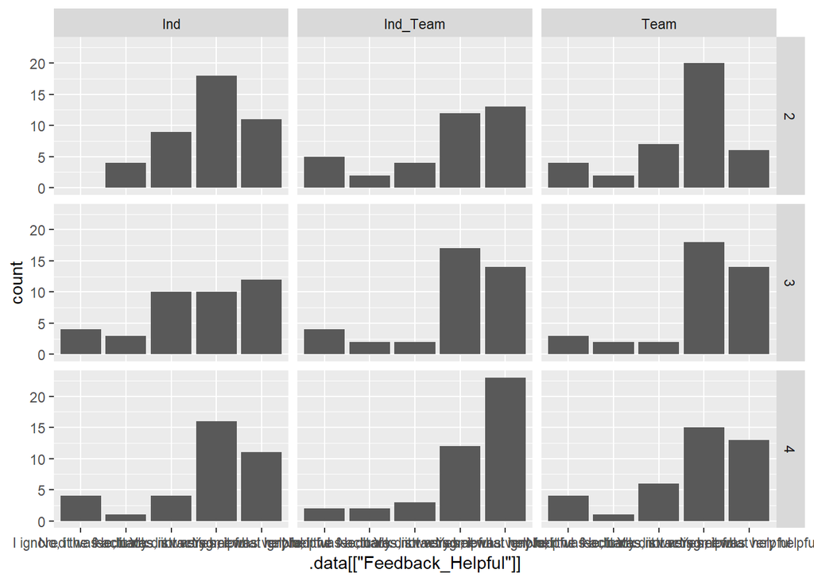

```r
y_label_ind <- "Count"
x_label_ind <- "Feedback_Helpful"
setwd(figure_directory)

plot_data_ind <- ind_data %>%
  select(x_label_ind,
         SessionOrder,
         Target)

ggplot(data = plot_data_ind, aes(x = .data[[x_label_ind]])) +
  geom_bar()+
  facet_grid(SessionOrder ~ Target) +
  xlim("I ignored the feedback", "No, it was actually distracting", "No, it was not very helpful", "Yes, it was somewhat helpful", "Yes, it was very helpful")
```

```r
summary_data<- plot_data_ind %>%
  group_by(SessionOrder, Target, .data[[x_label_ind]])%>%
  summarise(N = length(.data[[x_label_ind]]),
            percent = length(.data[[x_label_ind]])/ N_ind * 100)

summary_data %>%
  kable() %>%
  kable_styling()
```

| SessionOrder | Target | Feedback_Helpful | N | percent |
| --- | --- | --- | --- | --- |
| 2 | Ind | No, it was actually distracting | 4 | 3.4188034 |
| 2 | Ind | No, it was not very helpful | 9 | 7.6923077 |
| 2 | Ind | Yes, it was somewhat helpful | 18 | 15.3846154 |
| 2 | Ind | Yes, it was very helpful | 11 | 9.4017094 |
| 2 | Ind_Team | I ignored the feedback | 5 | 4.2735043 |
| 2 | Ind_Team | No, it was actually distracting | 2 | 1.7094017 |
| 2 | Ind_Team | No, it was not very helpful | 4 | 3.4188034 |
| 2 | Ind_Team | Yes, it was somewhat helpful | 12 | 10.2564103 |
| 2 | Ind_Team | Yes, it was very helpful | 13 | 11.1111111 |
| 2 | Team | I ignored the feedback | 4 | 3.4188034 |
| 2 | Team | No, it was actually distracting | 2 | 1.7094017 |
| 2 | Team | No, it was not very helpful | 7 | 5.9829060 |
| 2 | Team | Yes, it was somewhat helpful | 20 | 17.0940171 |
| 2 | Team | Yes, it was very helpful | 6 | 5.1282051 |
| 3 | Ind | I ignored the feedback | 4 | 3.4188034 |
| 3 | Ind | No, it was actually distracting | 3 | 2.5641026 |
| 3 | Ind | No, it was not very helpful | 10 | 8.5470085 |
| 3 | Ind | Yes, it was somewhat helpful | 10 | 8.5470085 |
| 3 | Ind | Yes, it was very helpful | 12 | 10.2564103 |
| 3 | Ind_Team | I ignored the feedback | 4 | 3.4188034 |
| 3 | Ind_Team | No, it was actually distracting | 2 | 1.7094017 |
| 3 | Ind_Team | No, it was not very helpful | 2 | 1.7094017 |
| 3 | Ind_Team | Yes, it was somewhat helpful | 17 | 14.5299145 |
| 3 | Ind_Team | Yes, it was very helpful | 14 | 11.9658120 |
| 3 | Team | I ignored the feedback | 3 | 2.5641026 |
| 3 | Team | No, it was actually distracting | 2 | 1.7094017 |
| 3 | Team | No, it was not very helpful | 2 | 1.7094017 |
| 3 | Team | Yes, it was somewhat helpful | 18 | 15.3846154 |
| 3 | Team | Yes, it was very helpful | 14 | 11.9658120 |
| 4 | Ind | I ignored the feedback | 4 | 3.4188034 |
| 4 | Ind | No, it was actually distracting | 1 | 0.8547009 |
| 4 | Ind | No, it was not very helpful | 4 | 3.4188034 |
| 4 | Ind | Yes, it was somewhat helpful | 16 | 13.6752137 |
| 4 | Ind | Yes, it was very helpful | 11 | 9.4017094 |
| 4 | Ind_Team | I ignored the feedback | 2 | 1.7094017 |
| 4 | Ind_Team | No, it was actually distracting | 2 | 1.7094017 |
| 4 | Ind_Team | No, it was not very helpful | 3 | 2.5641026 |
| 4 | Ind_Team | Yes, it was somewhat helpful | 12 | 10.2564103 |
| 4 | Ind_Team | Yes, it was very helpful | 23 | 19.6581197 |
| 4 | Team | I ignored the feedback | 4 | 3.4188034 |
| 4 | Team | No, it was actually distracting | 1 | 0.8547009 |
| 4 | Team | No, it was not very helpful | 6 | 5.1282051 |
| 4 | Team | Yes, it was somewhat helpful | 15 | 12.8205128 |
| 4 | Team | Yes, it was very helpful | 13 | 11.1111111 |

Generally, the number it looks like the feedback in each condition is more helpful over time. Something interesting is that that in the team condtion, in session 2 most participants found the feedback somewhat helpful and over time, most participants found the feedback either somewhat helpful or very helpful.

### Summary

Generally by session 4, participant the feedback in any condition somewhat helpful or helpful. It is interesting to note that in the Team and Ind_Team condition, participants consistantly found the feedback somewhat helpful or very helpful. In the Ind condition, it looks like the distribution needs some time to change over time.

## Did the participant feel as though their performance improved over time?

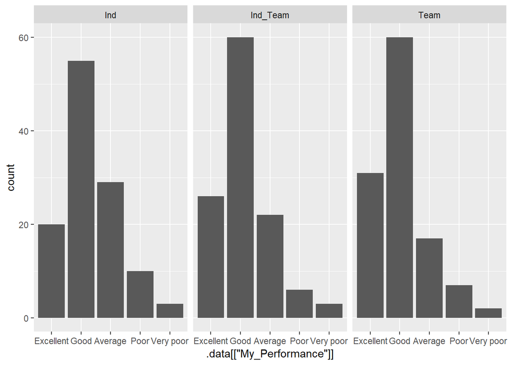

```r
y_label_ind <- "Count"
x_label_ind <- "My_Performance"
setwd(figure_directory)

plot_data_ind <- ind_data %>%
  select(x_label_ind,
         Target)

  ggplot(data = plot_data_ind, aes(x = .data[[x_label_ind]])) +
  geom_bar()+
  facet_grid(. ~ Target)+
  xlim("Excellent", "Good", "Average", "Poor", "Very poor")
```

```r
summary_data<- plot_data_ind %>%
  group_by(Target, .data[[x_label_ind]])%>%
  summarise(N = length(.data[[x_label_ind]]),
            percent = length(.data[[x_label_ind]])/ N_ind * 100)

summary_data %>%
  kable() %>%
  kable_styling()
```

| Target | My_Performance | N | percent |
| --- | --- | --- | --- |
| Ind | Average | 29 | 24.786325 |
| Ind | Excellent | 20 | 17.094017 |
| Ind | Good | 55 | 47.008547 |
| Ind | Poor | 10 | 8.547009 |
| Ind | Very poor | 3 | 2.564103 |
| Ind_Team | Average | 22 | 18.803419 |
| Ind_Team | Excellent | 26 | 22.222222 |
| Ind_Team | Good | 60 | 51.282051 |
| Ind_Team | Poor | 6 | 5.128205 |
| Ind_Team | Very poor | 3 | 2.564103 |
| Team | Average | 17 | 14.529915 |
| Team | Excellent | 31 | 26.495726 |
| Team | Good | 60 | 51.282051 |
| Team | Poor | 7 | 5.982906 |
| Team | Very poor | 2 | 1.709402 |

The distribution of the conditions look similar.

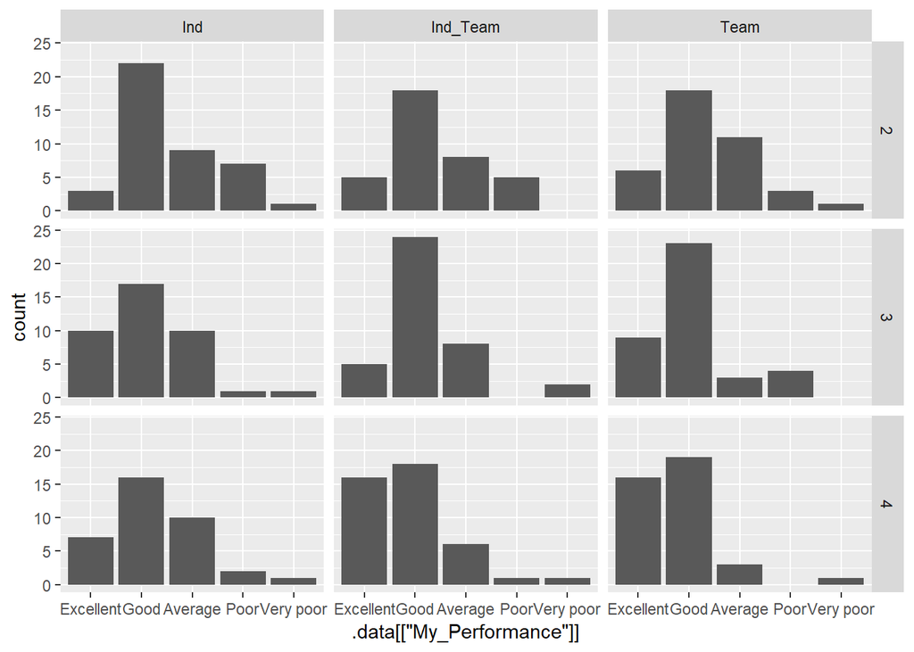

```r
y_label_ind <- "Count"
x_label_ind <- "My_Performance"
setwd(figure_directory)

plot_data_ind <- ind_data %>%
  select(x_label_ind,
         SessionOrder,
         Target)

ggplot(data = plot_data_ind, aes(x = .data[[x_label_ind]])) +
  geom_bar()+
  facet_grid(SessionOrder ~ Target) +
  xlim("Excellent", "Good", "Average", "Poor", "Very poor")
```

```r
summary_data<- plot_data_ind %>%
  group_by(SessionOrder, Target, .data[[x_label_ind]])%>%
  summarise(N = length(.data[[x_label_ind]]),
            percent = length(.data[[x_label_ind]])/ N_ind * 100)

summary_data %>%
  kable() %>%
  kable_styling()
```

| SessionOrder | Target | My_Performance | N | percent |
| --- | --- | --- | --- | --- |
| 2 | Ind | Average | 9 | 7.6923077 |
| 2 | Ind | Excellent | 3 | 2.5641026 |
| 2 | Ind | Good | 22 | 18.8034188 |
| 2 | Ind | Poor | 7 | 5.9829060 |
| 2 | Ind | Very poor | 1 | 0.8547009 |
| 2 | Ind_Team | Average | 8 | 6.8376068 |
| 2 | Ind_Team | Excellent | 5 | 4.2735043 |
| 2 | Ind_Team | Good | 18 | 15.3846154 |
| 2 | Ind_Team | Poor | 5 | 4.2735043 |
| 2 | Team | Average | 11 | 9.4017094 |
| 2 | Team | Excellent | 6 | 5.1282051 |
| 2 | Team | Good | 18 | 15.3846154 |
| 2 | Team | Poor | 3 | 2.5641026 |
| 2 | Team | Very poor | 1 | 0.8547009 |
| 3 | Ind | Average | 10 | 8.5470085 |
| 3 | Ind | Excellent | 10 | 8.5470085 |
| 3 | Ind | Good | 17 | 14.5299145 |
| 3 | Ind | Poor | 1 | 0.8547009 |
| 3 | Ind | Very poor | 1 | 0.8547009 |
| 3 | Ind_Team | Average | 8 | 6.8376068 |
| 3 | Ind_Team | Excellent | 5 | 4.2735043 |
| 3 | Ind_Team | Good | 24 | 20.5128205 |
| 3 | Ind_Team | Very poor | 2 | 1.7094017 |
| 3 | Team | Average | 3 | 2.5641026 |
| 3 | Team | Excellent | 9 | 7.6923077 |
| 3 | Team | Good | 23 | 19.6581197 |
| 3 | Team | Poor | 4 | 3.4188034 |
| 4 | Ind | Average | 10 | 8.5470085 |
| 4 | Ind | Excellent | 7 | 5.9829060 |
| 4 | Ind | Good | 16 | 13.6752137 |
| 4 | Ind | Poor | 2 | 1.7094017 |
| 4 | Ind | Very poor | 1 | 0.8547009 |
| 4 | Ind_Team | Average | 6 | 5.1282051 |
| 4 | Ind_Team | Excellent | 16 | 13.6752137 |
| 4 | Ind_Team | Good | 18 | 15.3846154 |
| 4 | Ind_Team | Poor | 1 | 0.8547009 |
| 4 | Ind_Team | Very poor | 1 | 0.8547009 |
| 4 | Team | Average | 3 | 2.5641026 |
| 4 | Team | Excellent | 16 | 13.6752137 |
| 4 | Team | Good | 19 | 16.2393162 |
| 4 | Team | Very poor | 1 | 0.8547009 |

Session 2, each condition seems to have a smiliar distribution. Session 3, participants in the Team and Ind_Team condition felt as though there individual performance was Good. In the Ind, most participants felt as though their performance was good, the same amount of participants thought their performance was average or excellent.

### Summary

When looking at the distribution over time, the data seems to suggest that the Ind_Team and Team condition has a similar influence on the self-percetion of individual performanc over time. In the Ind condition, it seems as though the Ind condtion has a different influence of perception of individual performance.

## Did the participant feel as though their performance improved over time?

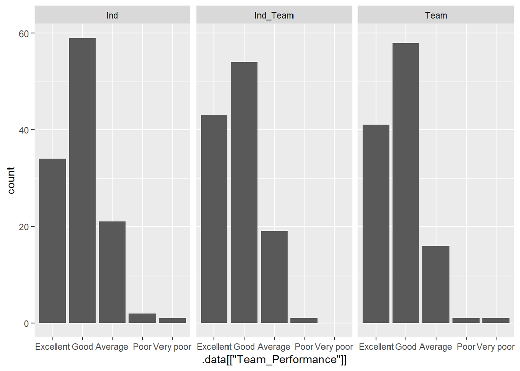

```r
y_label_ind <- "Count"
x_label_ind <- "Team_Performance"
setwd(figure_directory)

plot_data_ind <- ind_data %>%
  select(x_label_ind,
         Target)

  ggplot(data = plot_data_ind, aes(x = .data[[x_label_ind]])) +
  geom_bar()+
  facet_grid(. ~ Target)+
  xlim("Excellent", "Good", "Average", "Poor", "Very poor")
```

```r
summary_data<- plot_data_ind %>%
  group_by(Target, .data[[x_label_ind]])%>%
  summarise(N = length(.data[[x_label_ind]]),
            percent = length(.data[[x_label_ind]])/ N_ind * 100)

summary_data %>%
  kable() %>%
  kable_styling()
```

| Target | Team_Performance | N | percent |
| --- | --- | --- | --- |
| Ind | Average | 21 | 17.9487179 |
| Ind | Excellent | 34 | 29.0598291 |
| Ind | Good | 59 | 50.4273504 |
| Ind | Poor | 2 | 1.7094017 |
| Ind | Very poor | 1 | 0.8547009 |
| Ind_Team | Average | 19 | 16.2393162 |
| Ind_Team | Excellent | 43 | 36.7521368 |
| Ind_Team | Good | 54 | 46.1538462 |
| Ind_Team | Poor | 1 | 0.8547009 |
| Team | Average | 16 | 13.6752137 |
| Team | Excellent | 41 | 35.0427350 |
| Team | Good | 58 | 49.5726496 |
| Team | Poor | 1 | 0.8547009 |
| Team | Very poor | 1 | 0.8547009 |

Generally, the distribution of each condition is similar.

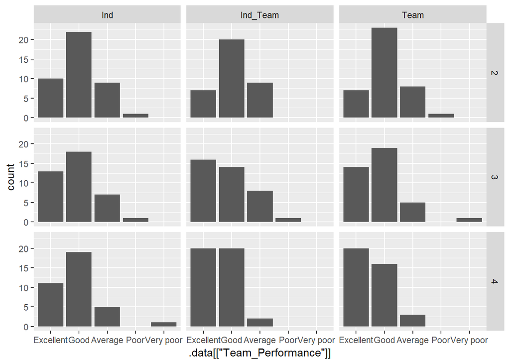

```r
y_label_ind <- "Count"
x_label_ind <- "Team_Performance"
setwd(figure_directory)

plot_data_ind <- ind_data %>%
  select(x_label_ind,
         SessionOrder,
         Target)

ggplot(data = plot_data_ind, aes(x = .data[[x_label_ind]])) +
  geom_bar()+
  facet_grid(SessionOrder ~ Target) +
  xlim("Excellent", "Good", "Average", "Poor", "Very poor")
```

```r
summary_data<- plot_data_ind %>%
  group_by(SessionOrder, Target, .data[[x_label_ind]])%>%
  summarise(N = length(.data[[x_label_ind]]),
            percent = length(.data[[x_label_ind]])/ N_ind * 100)

summary_data %>%
  kable() %>%
  kable_styling()
```

| SessionOrder | Target | Team_Performance | N | percent |
| --- | --- | --- | --- | --- |
| 2 | Ind | Average | 9 | 7.6923077 |
| 2 | Ind | Excellent | 10 | 8.5470085 |
| 2 | Ind | Good | 22 | 18.8034188 |
| 2 | Ind | Poor | 1 | 0.8547009 |
| 2 | Ind_Team | Average | 9 | 7.6923077 |
| 2 | Ind_Team | Excellent | 7 | 5.9829060 |
| 2 | Ind_Team | Good | 20 | 17.0940171 |
| 2 | Team | Average | 8 | 6.8376068 |
| 2 | Team | Excellent | 7 | 5.9829060 |
| 2 | Team | Good | 23 | 19.6581197 |
| 2 | Team | Poor | 1 | 0.8547009 |
| 3 | Ind | Average | 7 | 5.9829060 |
| 3 | Ind | Excellent | 13 | 11.1111111 |
| 3 | Ind | Good | 18 | 15.3846154 |
| 3 | Ind | Poor | 1 | 0.8547009 |
| 3 | Ind_Team | Average | 8 | 6.8376068 |
| 3 | Ind_Team | Excellent | 16 | 13.6752137 |
| 3 | Ind_Team | Good | 14 | 11.9658120 |
| 3 | Ind_Team | Poor | 1 | 0.8547009 |
| 3 | Team | Average | 5 | 4.2735043 |
| 3 | Team | Excellent | 14 | 11.9658120 |
| 3 | Team | Good | 19 | 16.2393162 |
| 3 | Team | Very poor | 1 | 0.8547009 |
| 4 | Ind | Average | 5 | 4.2735043 |
| 4 | Ind | Excellent | 11 | 9.4017094 |
| 4 | Ind | Good | 19 | 16.2393162 |
| 4 | Ind | Very poor | 1 | 0.8547009 |
| 4 | Ind_Team | Average | 2 | 1.7094017 |
| 4 | Ind_Team | Excellent | 20 | 17.0940171 |
| 4 | Ind_Team | Good | 20 | 17.0940171 |
| 4 | Team | Average | 3 | 2.5641026 |
| 4 | Team | Excellent | 20 | 17.0940171 |
| 4 | Team | Good | 16 | 13.6752137 |

Session 2, the distributions in each condition are similar. Session 3, the distribution of the Ind and Team condition are similar (i.e., most participants felt their performance was Excellent or Good). Session 4, the distributions seem similar.

### Summary

Overall, the distributions looks similar. However, over time, the distributions do not alwyas looks similar.